# Midterm 2

Berlin DeGroen

2021-02-28

## Instructions

Answer the following questions and complete the exercises in RMarkdown. Please embed all of your code and push your final work to your repository. Your code should be organized, clean, and run free from errors. Be sure to **add your name** to the author header above. You may use any resources to answer these questions (including each other), but you may not post questions to Open Stacks or external help sites. There are 10 total questions.

Make sure to use the formatting conventions of RMarkdown to make your report neat and clean! Your plots should use consistent aesthetics throughout. Feel free to be creative- there are many possible solutions to these questions!

This exam is due by **12:00p on Tuesday, February 23**.

## Load the libraries

```r
library(tidyverse)
library(janitor)
library(here)
options(scipen=999) #disables scientific notation when printing
```

## Gapminder

For this assignment, we are going to use data from [gapminder](https://www.gapminder.org/). Gapminder includes information about economics, population, social issues, and life expectancy from countries all over the world. We will use three data sets, so please load all three.

One thing to note is that the data include years beyond 2021. These are projections based on modeling done by the gapminder organization. Start by importing the data.

```r
population <- read_csv(here("midterm2", "data", "population_total.csv"))
population
```

```
## # A tibble: 195 x 302
##    country `1800` `1801` `1802` `1803` `1804` `1805` `1806` `1807` `1808` `1809`
##    <chr>    <dbl>  <dbl>  <dbl>  <dbl>  <dbl>  <dbl>  <dbl>  <dbl>  <dbl>  <dbl>
##  1 Afghan~ 3.28e6 3.28e6 3.28e6 3.28e6 3.28e6 3.28e6 3.28e6 3.28e6 3.28e6 3.28e6
##  2 Albania 4.00e5 4.02e5 4.04e5 4.05e5 4.07e5 4.09e5 4.11e5 4.13e5 4.14e5 4.16e5
##  3 Algeria 2.50e6 2.51e6 2.52e6 2.53e6 2.54e6 2.55e6 2.56e6 2.56e6 2.57e6 2.58e6
##  4 Andorra 2.65e3 2.65e3 2.65e3 2.65e3 2.65e3 2.65e3 2.65e3 2.65e3 2.65e3 2.65e3
##  5 Angola  1.57e6 1.57e6 1.57e6 1.57e6 1.57e6 1.57e6 1.57e6 1.57e6 1.57e6 1.57e6
##  6 Antigu~ 3.70e4 3.70e4 3.70e4 3.70e4 3.70e4 3.70e4 3.70e4 3.70e4 3.70e4 3.70e4
##  7 Argent~ 5.34e5 5.20e5 5.06e5 4.92e5 4.79e5 4.66e5 4.53e5 4.41e5 4.29e5 4.17e5
##  8 Armenia 4.13e5 4.13e5 4.13e5 4.13e5 4.13e5 4.13e5 4.13e5 4.13e5 4.13e5 4.13e5
##  9 Austra~ 2.00e5 2.05e5 2.11e5 2.16e5 2.22e5 2.27e5 2.33e5 2.39e5 2.46e5 2.52e5
## 10 Austria 3.00e6 3.02e6 3.04e6 3.05e6 3.07e6 3.09e6 3.11e6 3.12e6 3.14e6 3.16e6
## # ... with 185 more rows, and 291 more variables: 1810 <dbl>, 1811 <dbl>,
## #   1812 <dbl>, 1813 <dbl>, 1814 <dbl>, 1815 <dbl>, 1816 <dbl>, 1817 <dbl>,
## #   1818 <dbl>, 1819 <dbl>, 1820 <dbl>, 1821 <dbl>, 1822 <dbl>, 1823 <dbl>,
## #   1824 <dbl>, 1825 <dbl>, 1826 <dbl>, 1827 <dbl>, 1828 <dbl>, 1829 <dbl>,
## #   1830 <dbl>, 1831 <dbl>, 1832 <dbl>, 1833 <dbl>, 1834 <dbl>, 1835 <dbl>,
## #   1836 <dbl>, 1837 <dbl>, 1838 <dbl>, 1839 <dbl>, 1840 <dbl>, 1841 <dbl>,
## #   1842 <dbl>, 1843 <dbl>, 1844 <dbl>, 1845 <dbl>, 1846 <dbl>, 1847 <dbl>,
## #   1848 <dbl>, 1849 <dbl>, 1850 <dbl>, 1851 <dbl>, 1852 <dbl>, 1853 <dbl>,
## #   1854 <dbl>, 1855 <dbl>, 1856 <dbl>, 1857 <dbl>, 1858 <dbl>, 1859 <dbl>,
## #   1860 <dbl>, 1861 <dbl>, 1862 <dbl>, 1863 <dbl>, 1864 <dbl>, 1865 <dbl>,
## #   1866 <dbl>, 1867 <dbl>, 1868 <dbl>, 1869 <dbl>, 1870 <dbl>, 1871 <dbl>,
## #   1872 <dbl>, 1873 <dbl>, 1874 <dbl>, 1875 <dbl>, 1876 <dbl>, 1877 <dbl>,
## #   1878 <dbl>, 1879 <dbl>, 1880 <dbl>, 1881 <dbl>, 1882 <dbl>, 1883 <dbl>,
## #   1884 <dbl>, 1885 <dbl>, 1886 <dbl>, 1887 <dbl>, 1888 <dbl>, 1889 <dbl>,
## #   1890 <dbl>, 1891 <dbl>, 1892 <dbl>, 1893 <dbl>, 1894 <dbl>, 1895 <dbl>,
## #   1896 <dbl>, 1897 <dbl>, 1898 <dbl>, 1899 <dbl>, 1900 <dbl>, 1901 <dbl>,
## #   1902 <dbl>, 1903 <dbl>, 1904 <dbl>, 1905 <dbl>, 1906 <dbl>, 1907 <dbl>,
## #   1908 <dbl>, 1909 <dbl>, ...
```

```r
income <- read_csv(here("midterm2", "data", "income_per_person_gdppercapita_ppp_inflation_adjusted.csv"))
income
```

```
## # A tibble: 193 x 242
##    country `1800` `1801` `1802` `1803` `1804` `1805` `1806` `1807` `1808` `1809`
##    <chr>    <dbl>  <dbl>  <dbl>  <dbl>  <dbl>  <dbl>  <dbl>  <dbl>  <dbl>  <dbl>
##  1 Afghan~    603    603    603    603    603    603    603    603    603    603
##  2 Albania    667    667    667    667    667    668    668    668    668    668
##  3 Algeria    715    716    717    718    719    720    721    722    723    724
##  4 Andorra   1200   1200   1200   1200   1210   1210   1210   1210   1220   1220
##  5 Angola     618    620    623    626    628    631    634    637    640    642
##  6 Antigu~    757    757    757    757    757    757    757    758    758    758
##  7 Argent~   1640   1640   1650   1650   1660   1660   1670   1680   1680   1690
##  8 Armenia    514    514    514    514    514    514    514    514    514    514
##  9 Austra~    817    822    826    831    836    841    845    850    855    860
## 10 Austria   1850   1850   1860   1870   1880   1880   1890   1900   1910   1920
## # ... with 183 more rows, and 231 more variables: 1810 <dbl>, 1811 <dbl>,
## #   1812 <dbl>, 1813 <dbl>, 1814 <dbl>, 1815 <dbl>, 1816 <dbl>, 1817 <dbl>,
## #   1818 <dbl>, 1819 <dbl>, 1820 <dbl>, 1821 <dbl>, 1822 <dbl>, 1823 <dbl>,
## #   1824 <dbl>, 1825 <dbl>, 1826 <dbl>, 1827 <dbl>, 1828 <dbl>, 1829 <dbl>,
## #   1830 <dbl>, 1831 <dbl>, 1832 <dbl>, 1833 <dbl>, 1834 <dbl>, 1835 <dbl>,
## #   1836 <dbl>, 1837 <dbl>, 1838 <dbl>, 1839 <dbl>, 1840 <dbl>, 1841 <dbl>,
## #   1842 <dbl>, 1843 <dbl>, 1844 <dbl>, 1845 <dbl>, 1846 <dbl>, 1847 <dbl>,
## #   1848 <dbl>, 1849 <dbl>, 1850 <dbl>, 1851 <dbl>, 1852 <dbl>, 1853 <dbl>,
## #   1854 <dbl>, 1855 <dbl>, 1856 <dbl>, 1857 <dbl>, 1858 <dbl>, 1859 <dbl>,
## #   1860 <dbl>, 1861 <dbl>, 1862 <dbl>, 1863 <dbl>, 1864 <dbl>, 1865 <dbl>,
## #   1866 <dbl>, 1867 <dbl>, 1868 <dbl>, 1869 <dbl>, 1870 <dbl>, 1871 <dbl>,
## #   1872 <dbl>, 1873 <dbl>, 1874 <dbl>, 1875 <dbl>, 1876 <dbl>, 1877 <dbl>,
## #   1878 <dbl>, 1879 <dbl>, 1880 <dbl>, 1881 <dbl>, 1882 <dbl>, 1883 <dbl>,
## #   1884 <dbl>, 1885 <dbl>, 1886 <dbl>, 1887 <dbl>, 1888 <dbl>, 1889 <dbl>,
## #   1890 <dbl>, 1891 <dbl>, 1892 <dbl>, 1893 <dbl>, 1894 <dbl>, 1895 <dbl>,
## #   1896 <dbl>, 1897 <dbl>, 1898 <dbl>, 1899 <dbl>, 1900 <dbl>, 1901 <dbl>,
## #   1902 <dbl>, 1903 <dbl>, 1904 <dbl>, 1905 <dbl>, 1906 <dbl>, 1907 <dbl>,
## #   1908 <dbl>, 1909 <dbl>, ...
```

```r
life_expectancy <- read_csv(here("midterm2", "data", "life_expectancy_years.csv"))
life_expectancy
```

```
## # A tibble: 187 x 302
##    country `1800` `1801` `1802` `1803` `1804` `1805` `1806` `1807` `1808` `1809`
##    <chr>    <dbl>  <dbl>  <dbl>  <dbl>  <dbl>  <dbl>  <dbl>  <dbl>  <dbl>  <dbl>
##  1 Afghan~   28.2   28.2   28.2   28.2   28.2   28.2   28.1   28.1   28.1   28.1
##  2 Albania   35.4   35.4   35.4   35.4   35.4   35.4   35.4   35.4   35.4   35.4
##  3 Algeria   28.8   28.8   28.8   28.8   28.8   28.8   28.8   28.8   28.8   28.8
##  4 Andorra   NA     NA     NA     NA     NA     NA     NA     NA     NA     NA
##  5 Angola    27     27     27     27     27     27     27     27     27     27
##  6 Antigu~   33.5   33.5   33.5   33.5   33.5   33.5   33.5   33.5   33.5   33.5
##  7 Argent~   33.2   33.2   33.2   33.2   33.2   33.2   33.2   33.2   33.2   33.2
##  8 Armenia   34     34     34     34     34     34     34     34     34     34
##  9 Austra~   34     34     34     34     34     34     34     34     34     34
## 10 Austria   34.4   34.4   34.4   34.4   34.4   34.4   34.4   34.4   34.4   34.4
## # ... with 177 more rows, and 291 more variables: 1810 <dbl>, 1811 <dbl>,
## #   1812 <dbl>, 1813 <dbl>, 1814 <dbl>, 1815 <dbl>, 1816 <dbl>, 1817 <dbl>,
## #   1818 <dbl>, 1819 <dbl>, 1820 <dbl>, 1821 <dbl>, 1822 <dbl>, 1823 <dbl>,
## #   1824 <dbl>, 1825 <dbl>, 1826 <dbl>, 1827 <dbl>, 1828 <dbl>, 1829 <dbl>,
## #   1830 <dbl>, 1831 <dbl>, 1832 <dbl>, 1833 <dbl>, 1834 <dbl>, 1835 <dbl>,
## #   1836 <dbl>, 1837 <dbl>, 1838 <dbl>, 1839 <dbl>, 1840 <dbl>, 1841 <dbl>,
## #   1842 <dbl>, 1843 <dbl>, 1844 <dbl>, 1845 <dbl>, 1846 <dbl>, 1847 <dbl>,
## #   1848 <dbl>, 1849 <dbl>, 1850 <dbl>, 1851 <dbl>, 1852 <dbl>, 1853 <dbl>,
## #   1854 <dbl>, 1855 <dbl>, 1856 <dbl>, 1857 <dbl>, 1858 <dbl>, 1859 <dbl>,
## #   1860 <dbl>, 1861 <dbl>, 1862 <dbl>, 1863 <dbl>, 1864 <dbl>, 1865 <dbl>,
## #   1866 <dbl>, 1867 <dbl>, 1868 <dbl>, 1869 <dbl>, 1870 <dbl>, 1871 <dbl>,
## #   1872 <dbl>, 1873 <dbl>, 1874 <dbl>, 1875 <dbl>, 1876 <dbl>, 1877 <dbl>,
## #   1878 <dbl>, 1879 <dbl>, 1880 <dbl>, 1881 <dbl>, 1882 <dbl>, 1883 <dbl>,
## #   1884 <dbl>, 1885 <dbl>, 1886 <dbl>, 1887 <dbl>, 1888 <dbl>, 1889 <dbl>,
## #   1890 <dbl>, 1891 <dbl>, 1892 <dbl>, 1893 <dbl>, 1894 <dbl>, 1895 <dbl>,
## #   1896 <dbl>, 1897 <dbl>, 1898 <dbl>, 1899 <dbl>, 1900 <dbl>, 1901 <dbl>,
## #   1902 <dbl>, 1903 <dbl>, 1904 <dbl>, 1905 <dbl>, 1906 <dbl>, 1907 <dbl>,
## #   1908 <dbl>, 1909 <dbl>, ...
```

1. (3 points) Once you have an idea of the structure of the data, please make each data set tidy and store them as new objects. You will need both the original and tidy data!

```r
naniar::miss_var_summary(population)
```

```
## # A tibble: 302 x 3
##    variable n_miss pct_miss
##    <chr>     <int>    <dbl>
##  1 country       0        0
##  2 1800          0        0
##  3 1801          0        0
##  4 1802          0        0
##  5 1803          0        0
##  6 1804          0        0
##  7 1805          0        0
##  8 1806          0        0
##  9 1807          0        0
## 10 1808          0        0
## # ... with 292 more rows
```

```r
population_tidy <- population %>%
  pivot_longer(-country,
               names_to = "year",
               values_to = "population",
               values_drop_na = TRUE)
population_tidy
```

```
## # A tibble: 58,695 x 3
##    country     year  population
##    <chr>       <chr>      <dbl>
##  1 Afghanistan 1800     3280000
##  2 Afghanistan 1801     3280000
##  3 Afghanistan 1802     3280000
##  4 Afghanistan 1803     3280000
##  5 Afghanistan 1804     3280000
##  6 Afghanistan 1805     3280000
##  7 Afghanistan 1806     3280000
##  8 Afghanistan 1807     3280000
##  9 Afghanistan 1808     3280000
## 10 Afghanistan 1809     3280000
## # ... with 58,685 more rows
```

```r
naniar::miss_var_summary(income)
```

```
## # A tibble: 242 x 3
##    variable n_miss pct_miss
##    <chr>     <int>    <dbl>
##  1 country       0        0
##  2 1800          0        0
##  3 1801          0        0
##  4 1802          0        0
##  5 1803          0        0
##  6 1804          0        0
##  7 1805          0        0
##  8 1806          0        0
##  9 1807          0        0
## 10 1808          0        0
## # ... with 232 more rows
```

```r
income_tidy <- income %>%
  pivot_longer(-country,
               names_to = "year",
               values_to = "income",
               values_drop_na = TRUE)
income_tidy
```

```
## # A tibble: 46,513 x 3
##    country     year  income
##    <chr>       <chr>  <dbl>
##  1 Afghanistan 1800     603
##  2 Afghanistan 1801     603
##  3 Afghanistan 1802     603
##  4 Afghanistan 1803     603
##  5 Afghanistan 1804     603
##  6 Afghanistan 1805     603
##  7 Afghanistan 1806     603
##  8 Afghanistan 1807     603
##  9 Afghanistan 1808     603
## 10 Afghanistan 1809     603
## # ... with 46,503 more rows
```

```r
naniar::miss_var_summary(life_expectancy)
```

```
## # A tibble: 302 x 3
##    variable n_miss pct_miss
##    <chr>     <int>    <dbl>
##  1 1800          3     1.60
##  2 1801          3     1.60
##  3 1802          3     1.60
##  4 1803          3     1.60
##  5 1804          3     1.60
##  6 1805          3     1.60
##  7 1806          3     1.60
##  8 1807          3     1.60
##  9 1808          3     1.60
## 10 1809          3     1.60
## # ... with 292 more rows
```

```r
life_expecancy_tidy <- life_expectancy %>%
  pivot_longer(-country,
               names_to = "year",
               values_to = "life_expectancy_col",
               values_drop_na = TRUE)
life_expecancy_tidy
```

```
## # A tibble: 55,528 x 3
##    country     year  life_expectancy_col
##    <chr>       <chr>               <dbl>
##  1 Afghanistan 1800                 28.2
##  2 Afghanistan 1801                 28.2
##  3 Afghanistan 1802                 28.2
##  4 Afghanistan 1803                 28.2
##  5 Afghanistan 1804                 28.2
##  6 Afghanistan 1805                 28.2
##  7 Afghanistan 1806                 28.1
##  8 Afghanistan 1807                 28.1
##  9 Afghanistan 1808                 28.1
## 10 Afghanistan 1809                 28.1
## # ... with 55,518 more rows
```

2. (1 point) How many different countries are represented in the data? Provide the total number and their names. Since each data set includes different numbers of countries, you will need to do this for each one.

```r
population_tidy %>%
  summarize(n_country = n_distinct(country))
```

```
## # A tibble: 1 x 1
##   n_country
##       <int>
## 1       195
```

```r
population_tidy %>%
  distinct(country)
```

```
## # A tibble: 195 x 1
##    country
##    <chr>
##  1 Afghanistan
##  2 Albania
##  3 Algeria
##  4 Andorra
##  5 Angola
##  6 Antigua and Barbuda
##  7 Argentina
##  8 Armenia
##  9 Australia
## 10 Austria
## # ... with 185 more rows
```

```r
income_tidy %>%
  summarize(n_country = n_distinct(country))
```

```
## # A tibble: 1 x 1
##   n_country
##       <int>
## 1       193
```

```r
income_tidy %>%
  distinct(country)
```

```
## # A tibble: 193 x 1
##    country
##    <chr>
##  1 Afghanistan
##  2 Albania
##  3 Algeria
##  4 Andorra
##  5 Angola
##  6 Antigua and Barbuda
##  7 Argentina
##  8 Armenia
##  9 Australia
## 10 Austria
## # ... with 183 more rows
```

```r
life_expecancy_tidy %>%
  summarize(n_country = n_distinct(country))
```

```
## # A tibble: 1 x 1
##   n_country
##       <int>
## 1       187
```

```r
life_expecancy_tidy %>%
  distinct(country)
```

```
## # A tibble: 187 x 1
##    country
##    <chr>
##  1 Afghanistan
##  2 Albania
##  3 Algeria
##  4 Andorra
##  5 Angola
##  6 Antigua and Barbuda
##  7 Argentina
##  8 Armenia
##  9 Australia
## 10 Austria
## # ... with 177 more rows
```

## Life Expectancy

3. (2 points) Let’s limit the data to the past 100 years (1920-2020). For these years, which country has the highest life expectancy? How about the lowest life expectancy?

Highest

```r
life_expecancy_tidy %>%
  filter(year >= "1920" & year <= "2020") %>%
  group_by(country) %>%
  summarize(highest_life_expectancy = max(life_expectancy_col, na.rm = T)) %>%
  arrange(desc(highest_life_expectancy))
```

```
## # A tibble: 187 x 2
##    country     highest_life_expectancy
##    <chr>                         <dbl>
##  1 Singapore                      85.3
##  2 Japan                          84.7
##  3 Switzerland                    84.4
##  4 Italy                          83.6
##  5 Spain                          83.5
##  6 Israel                         83.4
##  7 Kuwait                         83.4
##  8 France                         83.2
##  9 Iceland                        83.2
## 10 South Korea                    83.2
## # ... with 177 more rows
```

Singapore had the highest life expectancy for that set of years.

```r
life_expecancy_tidy %>%
  filter(year >= "1920" & year <= "2020") %>%
  group_by(country) %>%
  arrange(desc(life_expectancy_col))
```

```
## # A tibble: 18,728 x 3
## # Groups:   country [187]
##    country     year  life_expectancy_col
##    <chr>       <chr>               <dbl>
##  1 Singapore   2020                 85.3
##  2 Singapore   2019                 85.1
##  3 Singapore   2018                 85
##  4 Singapore   2017                 84.8
##  5 Japan       2020                 84.7
##  6 Singapore   2016                 84.7
##  7 Japan       2019                 84.5
##  8 Japan       2018                 84.4
##  9 Singapore   2015                 84.4
## 10 Switzerland 2020                 84.4
## # ... with 18,718 more rows
```

Lowest

```r
life_expecancy_tidy %>%
  filter(year >= "1920" & year <= "2020") %>%
  group_by(country) %>%
  summarize(lowest_life_expectancy = min(life_expectancy_col, na.rm = T)) %>%
  arrange(lowest_life_expectancy)
```

```
## # A tibble: 187 x 2
##    country         lowest_life_expectancy
##    <chr>                            <dbl>
##  1 Kazakhstan                        4.07
##  2 Ukraine                           8.94
##  3 Rwanda                            9.64
##  4 Pakistan                         11.1
##  5 Kyrgyz Republic                  11.9
##  6 Lithuania                        12
##  7 Belarus                          13.9
##  8 Turkmenistan                     14.2
##  9 Poland                           15.4
## 10 Tajikistan                       15.7
## # ... with 177 more rows
```

```r
life_expecancy_tidy %>%
  filter(year >= "1920" & year <= "2020") %>%
  group_by(country) %>%
  arrange(life_expectancy_col)
```

```
## # A tibble: 18,728 x 3
## # Groups:   country [187]
##    country         year  life_expectancy_col
##    <chr>           <chr>               <dbl>
##  1 Kazakhstan      1933                 4.07
##  2 Kazakhstan      1932                 8.15
##  3 Ukraine         1933                 8.94
##  4 Rwanda          1994                 9.64
##  5 Pakistan        1947                11.1
##  6 Kyrgyz Republic 1921                11.9
##  7 Lithuania       1941                12
##  8 Belarus         1943                13.9
##  9 Kyrgyz Republic 1922                13.9
## 10 Turkmenistan    1933                14.2
## # ... with 18,718 more rows
```

Kazakhstan had the lowest life expectancy from that set of years.

4. (3 points) Although we can see which country has the highest life expectancy for the past 100 years, we don’t know which countries have changed the most. What are the top 5 countries that have experienced the biggest improvement in life expectancy between 1920-2020?

```r
life_expecancy_tidy %>%
  filter(year >= "1920" & year <= "2020") %>%
  group_by(country) %>%
  summarize(min_life_exp=min(life_expectancy_col),
            max_life_exp=max(life_expectancy_col)) %>%
  mutate(delta= max_life_exp-min_life_exp) %>%
  top_n(5, delta) %>%
  arrange(desc(delta))
```

```
## # A tibble: 5 x 4
##   country         min_life_exp max_life_exp delta
##   <chr>                  <dbl>        <dbl> <dbl>
## 1 Kazakhstan              4.07         73.1  69.0
## 2 Lithuania              12            75.6  63.6
## 3 Poland                 15.4          78.5  63.1
## 4 Ukraine                 8.94         71.8  62.9
## 5 Kyrgyz Republic        11.9          73.1  61.2
```

5. (3 points) Make a plot that shows the change over the past 100 years for the country with the biggest improvement in life expectancy. Be sure to add appropriate aesthetics to make the plot clean and clear. Once you have made the plot, do a little internet searching and see if you can discover what historical event may have contributed to this remarkable change.

```r
library("gapminder")
library(RColorBrewer)
library(ggthemes)
library(paletteer)
```

```r
#install.packages("trekcolors")
#remotes::install_github("leonawicz/trekcolors")
```

```r
library(trekcolors)
library(ggplot2)
```

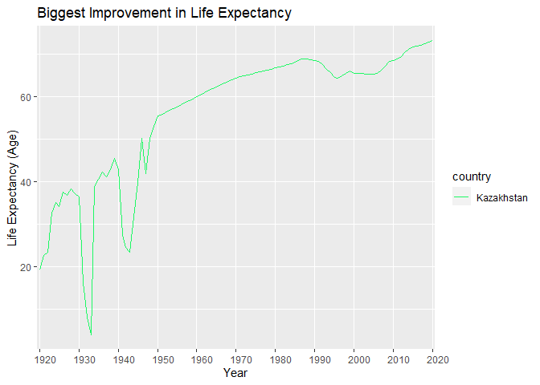

```r
life_expecancy_tidy %>%
  filter(year >= "1920" & year <= "2020") %>%
  filter(country=="Kazakhstan") %>%
  group_by(year, country) %>%
  ggplot(aes(x=year, y=life_expectancy_col, group=country, color=country))+
  geom_line()+
  theme(axis.text.x = element_text(hjust=0.25)) +
  labs(title = "Biggest Improvement in Life Expectancy",
       x = "Year",
       y = "Life Expectancy (Age)",
       fill = "Country")+
  scale_x_discrete(breaks = c("1920", "1930", "1940", "1950", "1960", "1970", "1980", "1990", "2000", "2010", "2020"))+
  scale_color_trek("romulan")
```

According to [Wikipedia](https://en.wikipedia.org/wiki/Kazakh_famine_of_1932%E2%80%9333), the large dip in life expectancy during the early 1930s was due to what was called the Kazakh famine, or the Goloshchyokin Genocide. This was a time in which much of Kazakhstan’s livestock and grain were confiscated to feed the cities, resulting in the deaths of 1.5-2.3 million people. Around 650,000 Kazakhs fled the country to avoid the famine. According to the [Borgen Project](https://borgenproject.org/10-facts-about-life-expectancy-in-kazakhstan/), life expectancy has been able to improve due to transitioning from lower-middle-income to upper-middle-income status in less than 2 decades. Another factor was immigration back into the country as well.

## Population Growth

6. (3 points) Which 5 countries have had the highest population growth over the past 100 years (1920-2020)?

```r
population_tidy %>%
  filter(year >= "1920" & year <= "2020") %>%
  group_by(country) %>%
  summarize(min_population=min(population),
            max_population=max(population)) %>%
  mutate(delta= max_population-min_population) %>%
  top_n(5, delta) %>%
  arrange(desc(delta))
```

```
## # A tibble: 5 x 4
##   country       min_population max_population      delta
##   <chr>                  <dbl>          <dbl>      <dbl>
## 1 India              317000000     1380000000 1063000000
## 2 China              472000000     1440000000  968000000
## 3 Indonesia           47300000      274000000  226700000
## 4 United States      111000000      331000000  220000000
## 5 Pakistan            21700000      221000000  199300000
```

7. (4 points) Produce a plot that shows the 5 countries that have had the highest population growth over the past 100 years (1920-2020). Which countries appear to have had exponential growth?

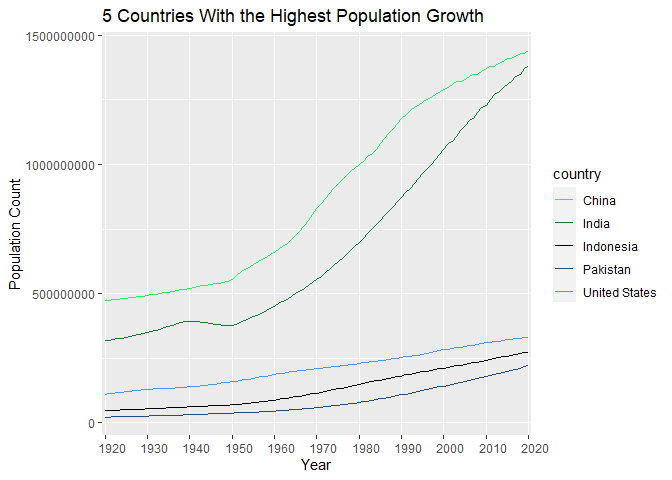

```r
population_tidy %>%
  filter(year >= "1920" & year <= "2020") %>%
  filter(country=="India" | country=="China" | country=="Indonesia" | country=="United States" | country=="Pakistan") %>%
  group_by(year, country) %>%
  ggplot(aes(x=year, y=population, group=country, color=country))+
  geom_line()+
  theme(axis.text.x = element_text(hjust=0.25)) +
  labs(title = "5 Countries With the Highest Population Growth",
       x = "Year",
       y = "Population Count",
       fill = "Country")+
  scale_x_discrete(breaks = c("1920", "1930", "1940", "1950", "1960", "1970", "1980", "1990", "2000", "2010", "2020"))+
  scale_color_trek("romulan")
```

## Income

The units used for income are gross domestic product per person adjusted for differences in purchasing power in international dollars.

8. (4 points) As in the previous questions, which countries have experienced the biggest growth in per person GDP. Show this as a table and then plot the changes for the top 5 countries. With a bit of research, you should be able to explain the dramatic downturns of the wealthiest economies that occurred during the 1980’s.

```r
income_tidy %>%
  filter(year >= "1920" & year <= "2020") %>%
  group_by(country) %>%
  summarize(min_income=min(income),
            max_income=max(income)) %>%
  mutate(delta= max_income-min_income) %>%
  top_n(5, delta) %>%
  arrange(desc(delta))
```

```
## # A tibble: 5 x 4
##   country              min_income max_income  delta
##   <chr>                     <dbl>      <dbl>  <dbl>
## 1 United Arab Emirates       1160     179000 177840
## 2 Qatar                      1080     178000 176920
## 3 Brunei                     2130     166000 163870
## 4 Kuwait                     1440     143000 141560
## 5 Luxembourg                 5730      97900  92170
```

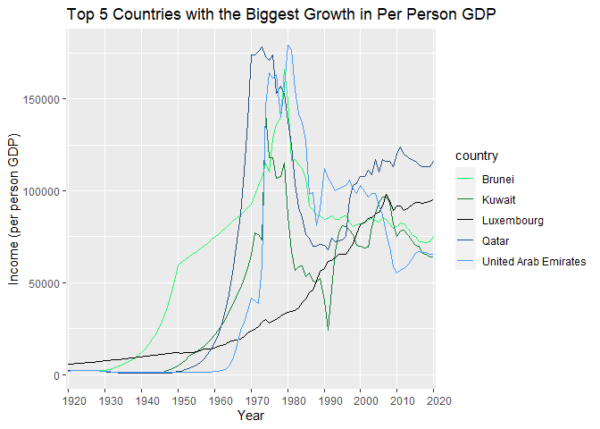

```r
income_tidy %>%
  filter(year >= "1920" & year <= "2020") %>%
  filter(country=="United Arab Emirates" | country=="Qatar" | country=="Brunei" | country=="Kuwait" | country=="Luxembourg") %>%
  group_by(year, country) %>%
  ggplot(aes(x=year, y=income, group=country, color=country))+
  geom_line()+
  theme(axis.text.x = element_text(hjust=0.25)) +
  labs(title = "Top 5 Countries with the Biggest Growth in Per Person GDP",
       x = "Year",
       y = "Income (per person GDP)",
       fill = "Country")+
  scale_x_discrete(breaks = c("1920", "1930", "1940", "1950", "1960", "1970", "1980", "1990", "2000", "2010", "2020"))+
  scale_color_trek("romulan")
```

The large dip in per person GDP during the early 1980s is due to the 1979 energy crisis, which was caused by the Iranian Revolution. Oil prices shot up from 1979-1980, causing the larger buying countries to increase their interest rates to control the inflation. High interest rates and high unemployment rates both contributed to the economic contraction that is shown in the countries on the graph. This information was sourced from [Wikipedia](https://en.wikipedia.org/wiki/Early_1980s_recession).

9. (3 points) Create three new objects that restrict each data set (life expectancy, population, income) to the years 1920-2020. Hint: I suggest doing this with the long form of your data. Once this is done, merge all three data sets using the code I provide below. You may need to adjust the code depending on how you have named your objects. I called mine `life_expectancy_100`, `population_100`, and `income_100`. For some of you, learning these `joins` will be important for your project.

life_expectancy_100

```r
life_expectancy_100 <- life_expecancy_tidy %>%
  filter(year >= "1920" & year <= "2020")
```

population_100

```r
population_100 <- population_tidy %>%
  filter(year >= "1920" & year <= "2020")
```

income_100

```r
income_100 <- income_tidy %>%
  filter(year >= "1920" & year <= "2020")
```

```r
gapminder_join <- inner_join(life_expectancy_100, population_100, by= c("country", "year"))
gapminder_join <- inner_join(gapminder_join, income_100, by= c("country", "year"))
gapminder_join
```

```
## # A tibble: 18,728 x 5
##    country     year  life_expectancy_col population income
##    <chr>       <chr>               <dbl>      <dbl>  <dbl>
##  1 Afghanistan 1920                 30.6   10600000   1490
##  2 Afghanistan 1921                 30.7   10500000   1520
##  3 Afghanistan 1922                 30.8   10300000   1550
##  4 Afghanistan 1923                 30.8    9710000   1570
##  5 Afghanistan 1924                 30.9    9200000   1600
##  6 Afghanistan 1925                 31      8720000   1630
##  7 Afghanistan 1926                 31      8260000   1650
##  8 Afghanistan 1927                 31.1    7830000   1680
##  9 Afghanistan 1928                 31.1    7420000   1710
## 10 Afghanistan 1929                 31.2    7100000   1740
## # ... with 18,718 more rows
```

10. (4 points) Use the joined data to perform an analysis of your choice. The analysis should include a comparison between two or more of the variables `life_expectancy`, `population`, or `income.`

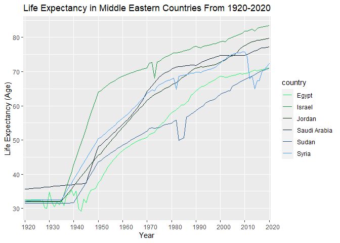

```r
gapminder_join %>%
  filter(country=="Sudan" | country=="Jordan" | country=="Syria" | country=="Saudi Arabia" | country=="Egypt" | country=="Israel") %>%
  group_by(year, country) %>%
  ggplot(aes(x=year, y=life_expectancy_col, group=country, color=country))+
  geom_line()+
  theme(axis.text.x = element_text(hjust=0.25)) +
  labs(title = "Life Expectancy in Middle Eastern Countries From 1920-2020",
       x = "Year",
       y = "Life Expectancy (Age)",
       fill = "Country")+
  scale_x_discrete(breaks = c("1920", "1930", "1940", "1950", "1960", "1970", "1980", "1990", "2000", "2010", "2020"))+
  scale_color_trek("romulan")
```

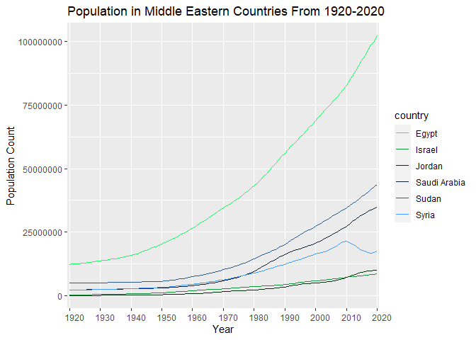

```r
gapminder_join %>%
  filter(country=="Sudan" | country=="Jordan" | country=="Syria" | country=="Saudi Arabia" | country=="Egypt" | country=="Israel") %>%
  group_by(year, country) %>%
  ggplot(aes(x=year, y=population, group=country, color=country))+
  geom_line()+
  theme(axis.text.x = element_text(hjust=0.25)) +
  labs(title = "Population in Middle Eastern Countries From 1920-2020",
       x = "Year",
       y = "Population Count",
       fill = "Country")+
  scale_x_discrete(breaks = c("1920", "1930", "1940", "1950", "1960", "1970", "1980", "1990", "2000", "2010", "2020"))+
  scale_color_trek("romulan")
```